# Análisis de realación entre variables

Mateo Espinal Londoño

22/3/2021

# 1. Pasos preliminares

Se cargan las librerías necesarias

```r
library(dplyr)
```

```r
library(ggplot2)
library(knitr)
```

## 1.1. Obtención de los datos:

Se crea el directorio donde se alojarán los diferentes conjuntos de datos

```r
#Verificación de la existencia del directorio
if(!dir.exists("./datos")){
  #Creación del directorio donde se alojarán los datos
  dir.create("./datos")
}
```

Se crea la función para descargar los conjuntos de dato

```r
#Función para descargar bases de datos
descargar_bd <- function(url_origen, destino_zip, nombre_archivo){

    #Se descarga el archivo .zip que contiene los conjuntos de datos
    download.file(url = url_origen, destfile = destino_zip, method = "curl")

    #Se extrae el .csv que contiene los datos
    unzip(zipfile =  ruta_destino,
          files = nombre_archivo,
          exdir = "./datos"
          )

    #se elimina el  .zip
    unlink(destino_zip)
}
```

Descarga del conjunto de datos de la composición del hogar

```r
#Se almacena el url del archivo
url <- "http://microdatos.dane.gov.co/index.php/catalog/678/download/13707"

#Se crea la ruta de destino del archivo
ruta_destino <- "./datos/compo_hogar.zip"

#Se crea el nombre del archivo a extraer
nombre_archivo<-"Caracteristicas y composicion del hogar.csv"

#Se descarga la base de datos usando la función creada previamente
descargar_bd(url, ruta_destino, nombre_archivo)
```

Lectura de la composición del hogar

```r
#Lectura de la composición del hogar
compo_hogar <- read.csv2(
  file = "./datos/Caracteristicas y composicion del hogar.csv",
  sep = ";",
  dec = ",",
  )

#Se cambia el nombre de la primera columna
colnames(compo_hogar)[1]<- "Directorio"

#Nombre de las columnas
#colnames(compo_hogar)
```

Encontramos el numero de hijos por hogar

```r
#Se cuentan el numero de hijos por hogar
hijos_hogar <- compo_hogar %>% select(Directorio,P6051) %>% filter(P6051 == 3) %>% count(Directorio)

#Se renombra la columna 2 como Hijos
colnames(hijos_hogar)[2] <- "Hijos"

head(hijos_hogar)
```

```
##   Directorio Hijos
## 1    7120001     1
## 2    7120002     5
## 3    7120009     1
## 4    7120010     3
## 5    7120016     2
## 6    7120018     2
```

Asignación de hijos a cada jefe de hogar

```r
#Se filtra el parentezco dejando solo a los jefes de hogar
jefe_hogar <- compo_hogar %>% filter(P6051 == 1)

#Se asocian los hijos a cada jefe de hogar
hijos_jefe <- merge(jefe_hogar, hijos_hogar, by = "Directorio", all = TRUE)

#A los jefe de hogar sin hijos se les establecen cero hijos
hijos_jefe$Hijos[is.na(hijos_jefe$Hijos)] <- 0
```

# 2. Estudio de las variables asignadas

## 2.1. variable P6080

Los ecuestados responden a la siguente pregunta: **De acuerdo con su cultura, pueblo o rasgos físicos, _____ es o se reconoce comó**

1. Indígena
2. Gitano (a) (Rom)
3. Raizal del archipiélago de San Andrés, Providencia y Santa Catalina
4. Palenquero (a) de San Basilio
5. Negro (a), mulato (a) (afrodescendiente), afrocolombiano(a)
6. Ninguno de los anteriores

```r
#Resumenes numericos
resumen_numerico <- tapply(hijos_jefe$Hijos, hijos_jefe$P6080, summary)

#Resumenes numericos como tabla
tabla<-do.call(rbind, resumen_numerico)

#Resumenes numericos mejor presentados
kable(tabla, row.names = TRUE)
```

|  | Min. | 1st Qu. | Median | Mean | 3rd Qu. | Max. |
| --- | --- | --- | --- | --- | --- | --- |
| 1 | 0 | 0 | 1 | 1.5941408 | 2.00 | 10 |
| 2 | 0 | 0 | 1 | 0.9473684 | 1.75 | 3 |
| 3 | 0 | 0 | 1 | 0.8122977 | 1.00 | 4 |
| 4 | 0 | 0 | 1 | 0.8333333 | 1.00 | 3 |
| 5 | 0 | 0 | 1 | 1.2384380 | 2.00 | 13 |
| 6 | 0 | 0 | 1 | 1.0750109 | 2.00 | 13 |

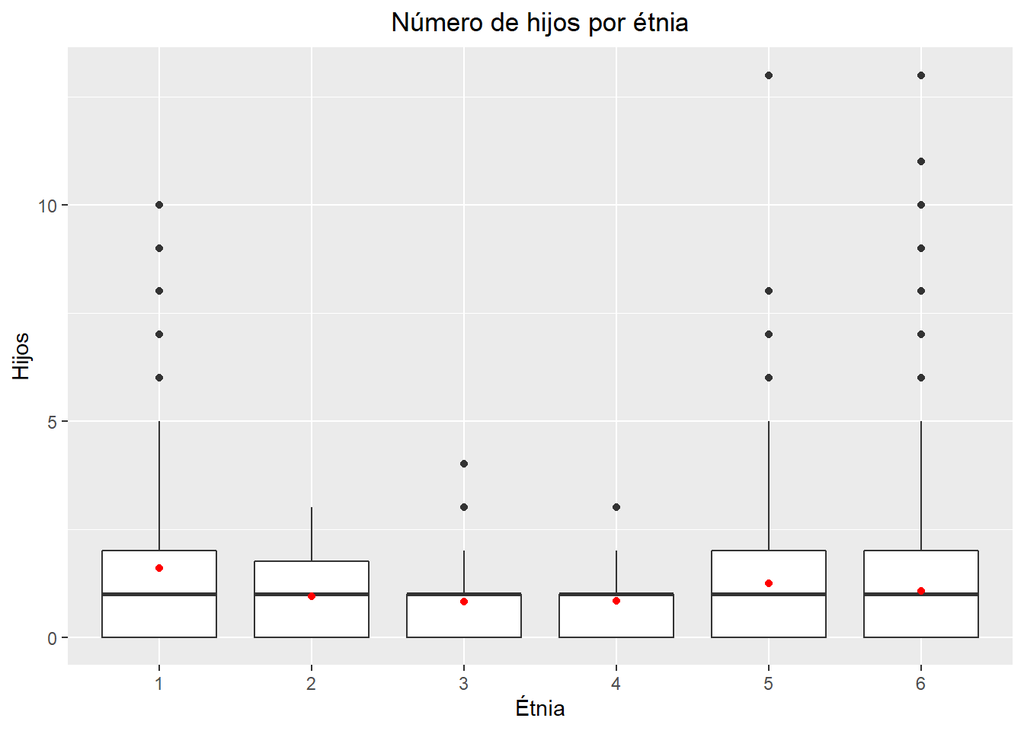

```r
mean_P6080 <- hijos_jefe %>%
  select(P6080,Hijos) %>%
  filter(!is.na(P6080)) %>%
  group_by(P6080) %>%
  dplyr::summarize(Hijos = mean(Hijos,na.rm=TRUE))

ggplot(hijos_jefe, aes(x = as.factor(P6080), y = Hijos)) +
    geom_boxplot() +
    xlab("Étnia") +
    ggtitle("Número de hijos por étnia")+
    theme(plot.title = element_text(hjust = 0.5))+
    geom_point(mean_P6080, mapping = aes(x = as.factor(P6080), y = Hijos),
               col = "Red")
```

**Nota:** Dado que la variable establece que a la pregunta *“Se toma información directamente a cada una de las personas del hogar de 18 años o más y de las personas entre 12 y 17 años que trabajen o sean estudiantes universitarios. La información de los menores de 12 años y de los jóvenes entre 12 y 17 años que no trabajen ni estudien en la universidad será suministrada por el padre, la madre o la persona del hogar que está a cargo de su cuidado, excluyendo el servicio doméstico.”*, Se considera que esta variable puede ser principalmente util para establecer la étnia del jefe de familia.

### Conclusión

Segun lo evidenciado en el gráfico anterior, se concluye que la étnia del jefe de familia no tiene gran incidencia en el número de hijos, pero dado que se presentan algunas variaciones entre las cajas de cada etnia, se considera dejarla dado que podría jugar un papel importante si se evalúa en conjunto con otras variables.

## 2.2. variable P6087

Los ecuestados responden a la siguente pregunta: **¿cuál es o fue el nivel de educación más alto alcanzado por el padre de…?**

1. Algunos años de primaria
2. Toda la primaria
3. Algunos años de secundaria
4. Toda la secundaria
5. Uno o mas años de técnica o tecnológica
6. Técnica o tecnológica completa
7. Uno o mas años de universidad
8. Universitaria completa
9. Ninguno
10. No sabe

```r
#Resumenes numericos
resumen_numerico <- tapply(hijos_jefe$Hijos, hijos_jefe$P6087, summary)

#Resumenes numericos como tabla
tabla<-do.call(rbind, resumen_numerico)

#Resumenes numericos mejor presentados
kable(tabla, row.names = TRUE)
```

|  | Min. | 1st Qu. | Median | Mean | 3rd Qu. | Max. |
| --- | --- | --- | --- | --- | --- | --- |
| 1 | 0 | 0 | 1 | 1.1552105 | 2 | 9 |
| 2 | 0 | 0 | 1 | 1.1431388 | 2 | 13 |
| 3 | 0 | 0 | 1 | 1.0930941 | 2 | 9 |
| 4 | 0 | 0 | 1 | 1.0126015 | 2 | 13 |
| 5 | 0 | 0 | 1 | 0.8370787 | 1 | 3 |
| 6 | 0 | 0 | 1 | 0.9155629 | 2 | 6 |
| 7 | 0 | 0 | 1 | 0.9419355 | 2 | 5 |
| 8 | 0 | 0 | 1 | 0.7812330 | 1 | 6 |
| 9 | 0 | 0 | 1 | 1.1853668 | 2 | 11 |
| 10 | 0 | 0 | 1 | 1.1391167 | 2 | 13 |

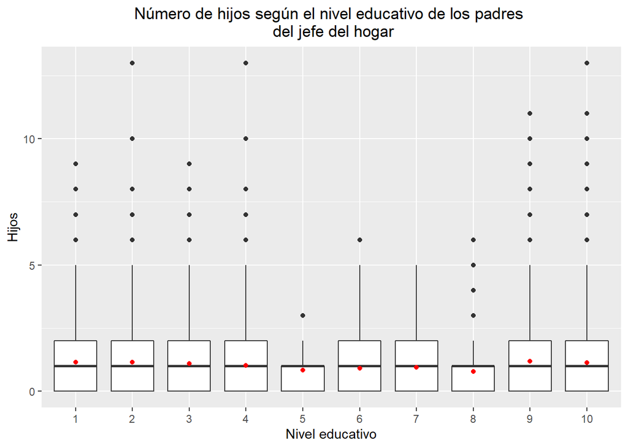

```r
mean_P6087 <- hijos_jefe %>%
  select(P6087,Hijos) %>%
  filter(!is.na(P6087)) %>%
  group_by(P6087) %>%
  dplyr::summarize(Hijos = mean(Hijos,na.rm=TRUE))


ggplot(subset(hijos_jefe, !is.na(P6087)), aes(x = as.factor(P6087), y = Hijos)) +
    geom_boxplot() +
    xlab("Nivel educativo") +
    ggtitle("Número de hijos según el nivel educativo de los padres \n del jefe del hogar")+
    theme(plot.title = element_text(hjust = 0.5))+
    geom_point(mean_P6087, mapping = aes(x = as.factor(P6087), y = Hijos),
               col = "Red")
```

**Nota**: En este caso se hace referencia a los padres del jefe de familia, dado que la variable contempla que *“Se busca establecer el nivel más alto de estudios que alcanzó el padre de la persona entrevistada, cuando este no vive en el hogar o es fallecido”* y *“Lo deben responder todas las personas del hogar. Se toma información directamente a cada una de las personas del hogar de 18 años o más y de las personas entre 12 y 17 años que trabajen o sean estudiantes universitarios”*, de lo anterior se infiere que la población de hijos del jefe de hojar comunmente no responde a esta pregunta. Por lo cual se concluye que esta variable puede ser utilizada principalmente para conocer los antecedentes familiares del jefe de familia, en este caso el nivel educativo de los padres del mismo.

### Conclusión

La conclusión para esta variable es similar a la anterior, inicialmente del gráfico se nota que el nivel educativo del padres del jefe de familia no tiene gran incidencia en el número de hijos, pero dado que se presentan algunas variaciones entre algunas cajas, se considera dejarla dado que podría jugar un papel importante si se evalúa en conjunto con otras variables.

## 2.3. variable P6020

Los ecuestados responden a la siguente pregunta: **Sexo**

1. Hombre
2. Mujer

```r
#Resumenes numericos
resumen_numerico <- tapply(hijos_jefe$Hijos, hijos_jefe$P6020, summary)

#Resumenes numericos como tabla
tabla<-do.call(rbind, resumen_numerico)

#Resumenes numericos mejor presentados
kable(tabla, row.names = TRUE)
```

|  | Min. | 1st Qu. | Median | Mean | 3rd Qu. | Max. |
| --- | --- | --- | --- | --- | --- | --- |
| 1 | 0 | 0 | 1 | 1.117995 | 2 | 13 |
| 2 | 0 | 0 | 1 | 1.175643 | 2 | 13 |

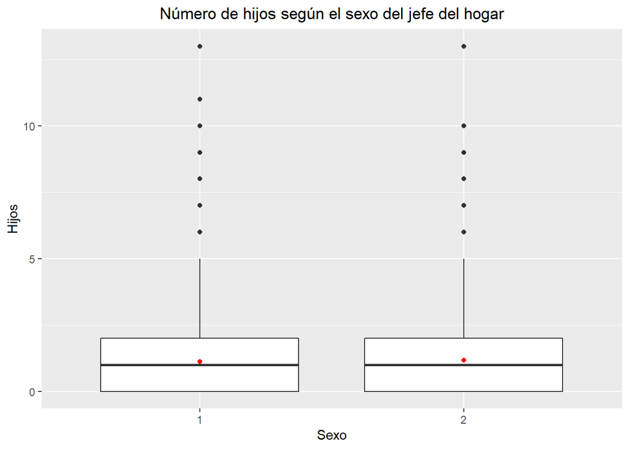

```r
mean_P6020 <- hijos_jefe %>%
  select(P6020,Hijos) %>%
  filter(!is.na(P6020)) %>%
  group_by(P6020) %>%
  dplyr::summarize(Hijos = mean(Hijos,na.rm=TRUE))

ggplot(subset(hijos_jefe, !is.na(P6020)), aes(x = as.factor(P6020), y = Hijos)) +
    geom_boxplot() +
    xlab("Sexo") +
    ggtitle("Número de hijos según el sexo del jefe del hogar")+
    theme(plot.title = element_text(hjust = 0.5))+
    geom_point(mean_P6020, mapping = aes(x = as.factor(P6020), y = Hijos),
               col = "Red")
```

### Conclusión:

En este caso las cajas del gráfico no presentan ningun tipo de diferencia significativa, por lo cual se cuestiona la relevancia de esta varaible, ya que si bien aqui no se presenta evidencia de dependencia, en juego con otras variables podría ser relevante.

## 2.4. variable P415

Los ecuestados responden a la siguente pregunta: **¿cuántas horas a la semana trabaja normalmente ____ en ese trabajo ?**

Obtención de los datos de fuerza de trabajo

```r
#Se almacena el url del archivo
url <- "http://microdatos.dane.gov.co/index.php/catalog/678/download/13711"

#Se crea la ruta de destino del archivo
ruta_destino <- "./datos/fuerza_de_trabajo.zip"

#Se crea el nombre del archivo a extraer
nombre_archivo<-"Fuerza de trabajo.csv"

#Se descarga la base de datos usando la función creada previamente
descargar_bd(url, ruta_destino, nombre_archivo)
```

Lectura de los datos de fuerza de trabajo

```r
#Lectura de la base de datos de fuerza de trabajo
fuerza_trabajo <- read.csv2(
  file = "./datos/Fuerza de trabajo.csv",
  sep = ";",
  dec = ",",
  )

#Se cambia el nombre de la primera columna
colnames(fuerza_trabajo)[1] <- "Directorio"

#De los jefes de familia de la base de datos de fuerza de trabajo se selecciona
#la variable que mide las horas trabajadas semanalmente
fuerza_trabajo <- fuerza_trabajo %>% filter(ORDEN == 1) %>% select(Directorio,P415)

#Se añade la variable al conjunto de datos hijos_jefe
hijos_jefe <- merge(hijos_jefe, fuerza_trabajo, by = "Directorio", all = TRUE)
```

Gráfico de dispersión

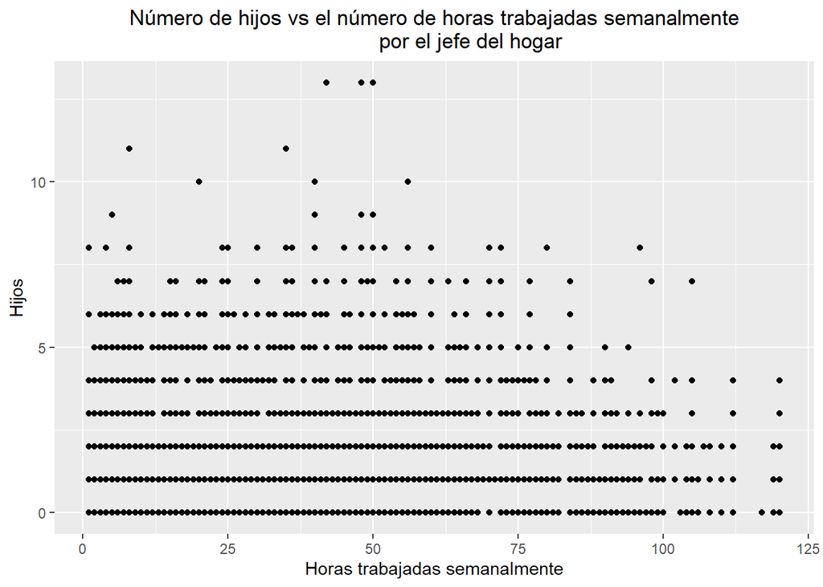

```r
#Se raliza el gráfico de dispersión del numero de hijos por las horas trabajadas
#semanalmente
ggplot(subset(hijos_jefe, !is.na(P415)), aes(x = P415, y = Hijos))+
    geom_point() +
    xlab("Horas trabajadas semanalmente") +
    ggtitle("Número de hijos vs el número de horas trabajadas semanalmente
            por el jefe del hogar")+
    theme(plot.title = element_text(hjust = 0.5))
```

Calculo del indice de correlación

```r
hijos_jefe %>% select(Hijos, P415) %>% filter(!is.na(P415)) %>% cor()
```

```
##           Hijos      P415
## Hijos 1.0000000 0.0170794
## P415  0.0170794 1.0000000
```

### Conclusión:

Se concluye que el número de horas trabajadas por el jefe de familia no tiene relación con el número de hijos.

## 2.5. variable P8520S3

Los ecuestados responden a la siguente pregunta: **¿Con cuáles de los siguientes servicios públicos, privados o comunales cuenta la vivienda?** 3. Alcantarillado

1. Sí
2. No

Descarga del conjunto de datos “Datos de la vivienda”

```r
#Se almacena el url del archivo
url <- "http://microdatos.dane.gov.co/index.php/catalog/678/download/13705"

#Se crea la ruta de destino del archivo
ruta_destino <- "./datos/datos_vivienda.zip"

#Se crea el nombre del archivo a extraer
nombre_archivo<-"Datos de la vivienda.csv"

#Se descarga la base de datos usando la función creada previamente
descargar_bd(url, ruta_destino, nombre_archivo)
```

Lectura de los datos de la vivienda

```r
datos_vivienda <- read.csv2(
  file = "./datos/datos de la vivienda.csv",
  sep = ";",
  dec = ",",
  )

#Se cambia el nombre de la primera columna
colnames(datos_vivienda)[1] <- "Directorio"

datos_vivienda <- datos_vivienda %>% select(Directorio, P8520S3)

hijos_jefe <- merge(hijos_jefe, datos_vivienda, by = "Directorio", all = TRUE)
```

Resumen numerico de los datos de la vivienda

```r
#Resumenes numericos
resumen_numerico <- tapply(hijos_jefe$Hijos, hijos_jefe$P8520S3, summary)

#Resumenes numericos como tabla
tabla<-do.call(rbind, resumen_numerico)

#Resumenes numericos mejor presentados
kable(tabla, row.names = TRUE)
```

|  | Min. | 1st Qu. | Median | Mean | 3rd Qu. | Max. |
| --- | --- | --- | --- | --- | --- | --- |
| 1 | 0 | 0 | 1 | 1.133988 | 2 | 13 |
| 2 | 0 | 0 | 1 | 1.205469 | 2 | 11 |

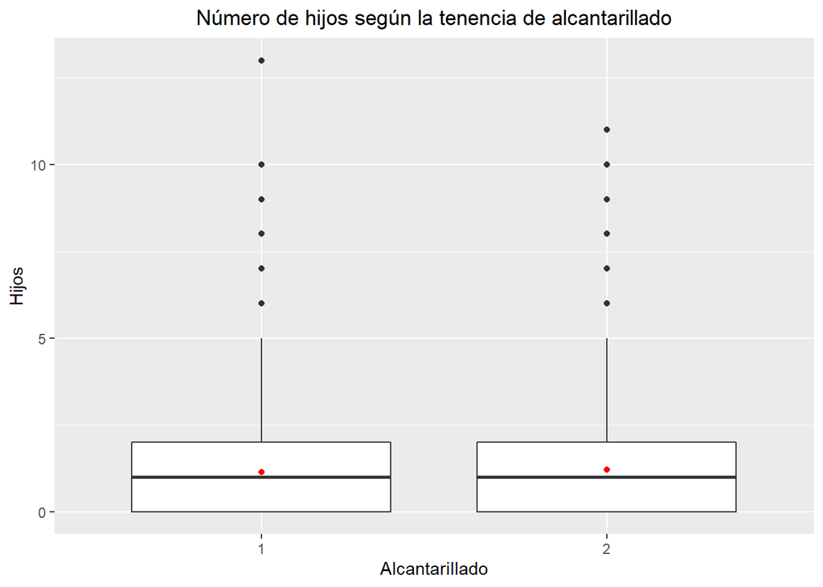

```r
mean_P8520S3 <- hijos_jefe %>%
  select(P8520S3,Hijos) %>%
  filter(!is.na(P8520S3)) %>%
  group_by(P8520S3) %>%
  dplyr::summarize(Hijos = mean(Hijos,na.rm=TRUE))

ggplot(hijos_jefe, aes(x = as.factor(P8520S3), y = Hijos)) +
    geom_boxplot() +
    xlab("Alcantarillado") +
    ggtitle("Número de hijos según la tenencia de alcantarillado")+
    theme(plot.title = element_text(hjust = 0.5)) +
    geom_point(mean_P8520S3, mapping = aes(x = as.factor(P8520S3), y = Hijos),
               col = "Red")
```

### Conclusión:

Dado que no se aprecian diferencias significaivas en las cajas del gráfico anterior, se considera que la tenencia de alcantarillado en el hogar no tiene relación con el número de hijos por hogar.

## 2.6. variable P1899

Los ecuestados responden a la siguente pregunta: **En general, qué tan satisfecho(a) se siente … con su trabajo/actividad actualmente?**

Resumenes numericos

```r
#Resumenes numericos
resumen_numerico <- tapply(hijos_jefe$Hijos, hijos_jefe$P1899, summary)

#Resumenes numericos como tabla
tabla<-do.call(rbind, resumen_numerico)

#Resumenes numericos mejor presentados
kable(tabla, row.names = TRUE)
```

|  | Min. | 1st Qu. | Median | Mean | 3rd Qu. | Max. |
| --- | --- | --- | --- | --- | --- | --- |
| 0 | 0 | 0 | 1 | 1.203564 | 2 | 9 |
| 1 | 0 | 0 | 1 | 1.223457 | 2 | 8 |
| 2 | 0 | 0 | 1 | 1.239322 | 2 | 10 |
| 3 | 0 | 0 | 1 | 1.225149 | 2 | 10 |
| 4 | 0 | 0 | 1 | 1.248801 | 2 | 10 |
| 5 | 0 | 0 | 1 | 1.210945 | 2 | 13 |
| 6 | 0 | 0 | 1 | 1.210811 | 2 | 13 |
| 7 | 0 | 0 | 1 | 1.215021 | 2 | 9 |
| 8 | 0 | 0 | 1 | 1.156772 | 2 | 13 |
| 9 | 0 | 0 | 1 | 1.147730 | 2 | 10 |
| 10 | 0 | 0 | 1 | 1.085059 | 2 | 11 |

Creación del boxplot

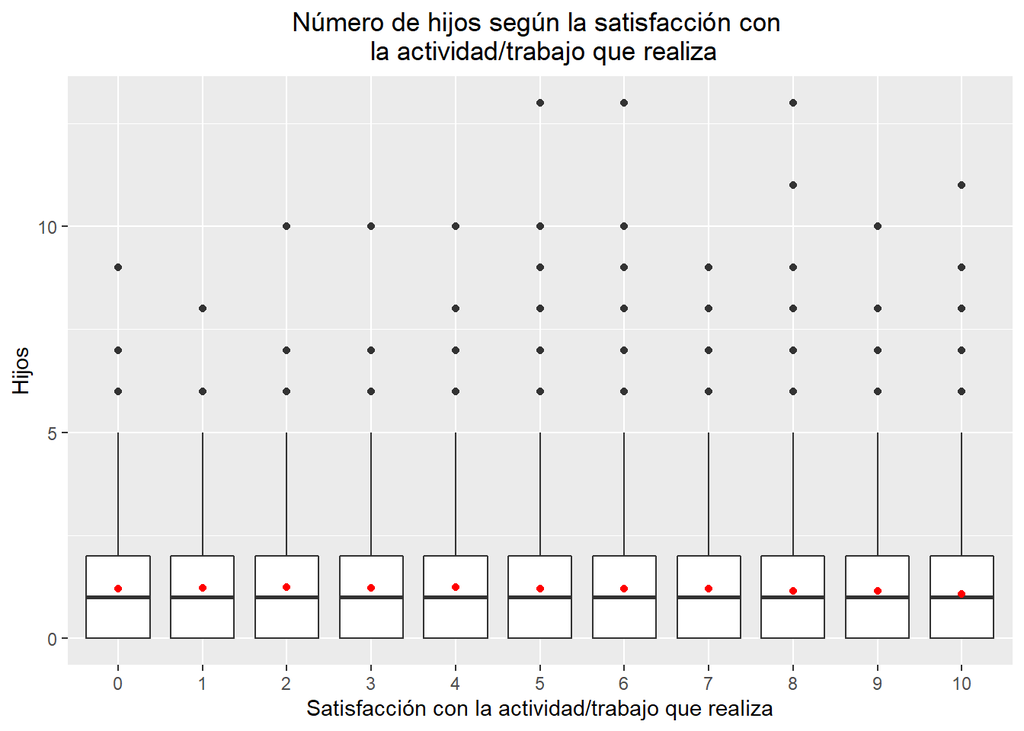

```r
mean_P1899 <- hijos_jefe %>%
  select(P1899,Hijos) %>%
  filter(!is.na(P1899)) %>%
  group_by(P1899) %>%
  dplyr::summarize(Hijos = mean(Hijos,na.rm=TRUE))

ggplot(subset(hijos_jefe, !is.na(P1899)), aes(x = as.factor(P1899), y = Hijos)) +
    geom_boxplot() +
    xlab("Satisfacción con la actividad/trabajo que realiza") +
    ggtitle("Número de hijos según la satisfacción con \n la actividad/trabajo que realiza")+
    theme(plot.title = element_text(hjust = 0.5)) +
    geom_point(mean_P1899, mapping = aes(x = as.factor(P1899), y = Hijos),
               col = "Red")
```

# 3. Estudio de las variables del conjunto de datos “Tenencia y financiación de la vivienda que ocupa el hogar”

Lectura del conjunto de datos

```r
tenencia <- read.csv2(
  file = "./datos/Tenencia y financiación de la vivienda que ocupa el hogar.csv",
  sep = ";",
  dec = ","
  )

#Se cambia el nombre de la primera columna
colnames(tenencia)[1] <- "Directorio"
```

## 3.1. P5095

Los ecuestados responden a la siguente pregunta: **La vivienda ocupada por este hogar es:**

1. Propia, totalmente pagada
2. Propia, la están pagando
3. En arriendo o subarriendo
4. Con permiso del propietario, sin pago alguno (usufructuario)
5. Posesión sin título (ocupante de hecho)
6. Propiedad colectiva

Unión de la variable con el conjunto de datos de jefe de hogar

```r
datos_vivienda <- tenencia %>% select(Directorio, P5095)

hijos_jefe <- merge(hijos_jefe, datos_vivienda, by = "Directorio", all = TRUE)
```

Resumenes numéricos

```r
#Resumenes numericos
resumen_numerico <- tapply(hijos_jefe$Hijos, hijos_jefe$P5095, summary)

#Resumenes numericos como tabla
tabla<-do.call(rbind, resumen_numerico)

#Resumenes numericos mejor presentados
kable(tabla, row.names = TRUE)
```

|  | Min. | 1st Qu. | Median | Mean | 3rd Qu. | Max. |
| --- | --- | --- | --- | --- | --- | --- |
| 1 | 0 | 0 | 1 | 1.141373 | 2 | 11 |
| 2 | 0 | 0 | 1 | 1.272691 | 2 | 6 |
| 3 | 0 | 0 | 1 | 1.254733 | 2 | 13 |
| 4 | 0 | 0 | 1 | 1.351237 | 2 | 10 |
| 5 | 0 | 0 | 1 | 1.534524 | 2 | 10 |
| 6 | 0 | 0 | 1 | 1.574623 | 2 | 10 |

Creación del boxplot

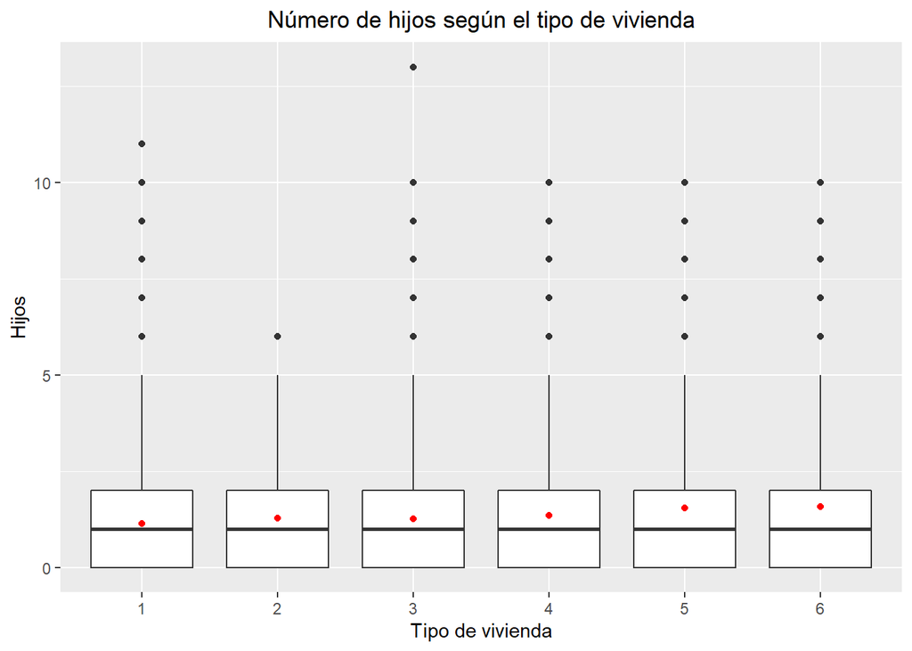

```r
mean_P5095 <- hijos_jefe %>%
  select(P5095,Hijos) %>%
  filter(!is.na(P5095)) %>% group_by(P5095) %>%
  dplyr::summarize(Hijos = mean(Hijos,na.rm=TRUE))

ggplot(subset(hijos_jefe, !is.null(P5095)), aes(x = as.factor(P5095), y = Hijos)) +
    geom_boxplot() +
    xlab("Tipo de vivienda") +
    ggtitle("Número de hijos según el tipo de vivienda")+
    theme(plot.title = element_text(hjust = 0.5)) +
    geom_point(mean_P5095, mapping = aes(x = as.factor(P5095), y = Hijos),
               col = "Red")
```

### Conclusión:

Dado que no se aprecian diferencias significaivas en las cajas del gráfico anterior, se considera que el tipo de vivienda no tiene relación con el número de hijos por hogar.

**Duda con el comportamiento de la media.**

## Nota:

Dado que el resto de variables del conjunto dependen de desta y no se aprecia una relación importante con el numero de hijos, **no se consideran**.